# Project Notebook

Sports Group

```r
library(readr)
library(tidyverse)
library(ggrepel)
library(tidymodels)
library(rpart.plot)
```

# Data Sets

```r
# 1. Course Data
course_url <- "https://raw.githubusercontent.com/wkessler-oss/PGA-Tour-ML-Analysis/main/Course%20Data.csv"
course_data <- read_csv(course_url)

# 2. Player Data
master_url <- "https://raw.githubusercontent.com/wkessler-oss/PGA-Tour-ML-Analysis/main/PGA_2025_Master.csv"
pga_master <- read_csv(master_url)

pga_master <- pga_master %>%
  mutate(
    # Clean to_par
    to_par = case_when(
      to_par == "E" ~ "0",
      TRUE ~ to_par
    ),
    to_par = as.numeric(to_par),

    # Convert all round scores and total to numeric
    r1    = as.numeric(r1),
    r2    = as.numeric(r2),
    r3    = as.numeric(r3),
    r4    = as.numeric(r4),
    total = as.numeric(total)
  )

# Make sure it came in correctly
head(course_data)
```

| course | par | yardage | yardage_4_5 | yardage_3 | adj_score_to_par | adj_par_3_score | adj_par_4_score | adj_par_5_score | adj_driving_distance | adj_sd_distance | adj_driving_accuracy | putt_sg | arg_sg | app_sg | ott_sg | fw_width | fw_diff | rgh_diff | non_rgh_diff | miss_fw_pen_frac | adj_gir | less_150_sg | greater_150_sg | arg_fairway_sg | arg_rough_sg | arg_bunker_sg | less_5_ft_sg | greater_5_less_15_sg | greater_15_sg | … |
| --- | --- | --- | --- | --- | --- | --- | --- | --- | --- | --- | --- | --- | --- | --- | --- | --- | --- | --- | --- | --- | --- | --- | --- | --- | --- | --- | --- | --- | --- | --- |
| Castle Pines Golf Club | 72 | 7981 | 511 | 208 | 0.38 | 0.09 | 0.13 | -0.33 | 323.2 | 19.3 | 0.6338 | 0.007 | -0.041 | -0.004 | 0.097 | 34.6 | 0.48 | 0.49 | 0.40 | 0.0617 | 0.6351 | -0.078 | 0.030 | 0.003 | -0.12 | -0.017 | 0.005 | -0.003 | 0.017 | … |
| Erin Hills | 72 | 7723 | 497 | 197 | 1.35 | 0.10 | 0.12 | -0.07 | 294.7 | 20.4 | 0.7454 | -0.011 | -0.074 | -0.002 | 0.016 | 48.8 | 0.54 | 0.49 | 0.56 | 0.0170 | 0.6485 | -0.059 | 0.023 | -0.086 | -0.149 | -0.172 | 0.003 | 0.004 | -0.046 | … |
| Ocean Course at Kiawah Island | 72 | 7671 | 489 | 207 | 2.57 | 0.29 | 0.21 | -0.17 | 293.0 | 17.9 | 0.5894 | -0.005 | -0.020 | -0.056 | -0.017 | 36.7 | 0.40 | 0.32 | 0.31 | 0.0616 | 0.5320 | -0.089 | -0.044 | -0.007 | -0.04 | -0.288 | -0.007 | -0.012 | 0.004 | … |
| Torrey Pines South (U.S. Open) | 71 | 7635 | 490 | 194 | 2.57 | 0.18 | 0.20 | -0.12 | 300.8 | 17.8 | 0.4870 | -0.014 | -0.020 | -0.027 | -0.003 | 28.9 | 0.30 | 0.27 | 0.33 | 0.0111 | 0.5615 | -0.049 | -0.017 | 0.005 | -0.034 | -0.021 | -0.005 | -0.025 | -0.019 | … |
| Torrey Pines South (Genesis Inv.) | 72 | 7599 | 488 | 190 | 1.11 | 0.12 | 0.17 | -0.26 | 290.5 | 14.9 | 0.5366 | -0.026 | 0.033 | -0.006 | -0.063 | 27.8 | 0.32 | 0.28 | 0.30 | 0.0209 | 0.6153 | 0.004 | -0.010 | 0.053 | 0.008 | 0.043 | -0.016 | -0.066 | -0.011 | … |
| Torrey Pines Golf Course (South Course) | 72 | 7593 | 487 | 194 | 1.08 | 0.09 | 0.17 | -0.25 | 290.5 | 15.7 | 0.5299 | -0.018 | 0.001 | -0.001 | -0.026 | 26.8 | 0.34 | 0.31 | 0.34 | 0.0174 | 0.6110 | -0.013 | 0.004 | 0.024 | -0.018 | -0.004 | -0.012 | -0.042 | -0.007 | … |

```r
head(pga_master)
```

| player_id | player | season | start_date | tournament_name | course_name | finish_pos | r1 | r2 | r3 | r4 | total | to_par | sg_total | sg_ott | sg_app | sg_arg | sg_putt | sg_rounds |
| --- | --- | --- | --- | --- | --- | --- | --- | --- | --- | --- | --- | --- | --- | --- | --- | --- | --- | --- |
| 51997 | Andrew Novak | 2025 | 2025-05-08 | Truist Championship | The Philadelphia Cricket Club (Wissahickon Course) | T17 | 66 | 71 | 72 | 64 | 273 | -7 | 0.762 | -0.108 | 0.256 | 0.650 | -0.035 | 4 |
| 51997 | Andrew Novak | 2025 | 2025-05-15 | PGA Championship | Quail Hollow Club | CUT | 70 | 80 | NA | NA | 150 | 8 | -2.413 | -0.781 | -1.471 | 0.423 | -0.583 | 2 |
| 51997 | Andrew Novak | 2025 | 2025-05-22 | Charles Schwab Challenge | Colonial Country Club | T11 | 67 | 69 | 67 | 71 | 274 | -6 | 1.827 | 0.870 | 0.997 | 0.237 | -0.277 | 4 |
| 51997 | Andrew Novak | 2025 | 2025-05-29 | the Memorial Tournament presented by Workday | Muirfield Village Golf Club | T51 | 70 | 77 | 75 | 77 | 299 | 11 | -1.380 | 0.383 | 0.212 | -1.984 | 0.010 | 4 |
| 51997 | Andrew Novak | 2025 | 2025-06-12 | U.S. Open | Oakmont Country Club | T42 | 76 | 71 | 73 | 72 | 292 | 12 | NA | NA | NA | NA | NA | NA |
| 51997 | Andrew Novak | 2025 | 2025-06-19 | Travelers Championship | TPC River Highlands | T30 | 70 | 71 | 69 | 66 | 276 | -4 | 0.491 | 0.132 | -0.305 | 0.427 | -0.014 | 4 |

### Dimensions

```r
dim(course_data)
```

```
[1] 111  32
```

```r
dim(pga_master)
```

```
[1] 1755   19
```

The player dataset contains 1,755 rows and 19 columns. Each row represents one player’s participation in a particular tournament during the 2025 season. The columns describe the player, tournament, course, finishing position, individual round scores, total score, score relative to par, and strokes-gained performance. Players appear in multiple rows because they compete in multiple tournaments.

The course dataset contains 111 rows and 32 columns. Each row represents a golf course or a specific course setup, since some courses have separate entries for different events or par configurations. The columns describe course characteristics and playing statistics, including par, yardage, adjusted scoring, adjusted driving distance, driving accuracy, fairway width, and greens in regulation.

## Data Set Descriptions

### Assumptions

We assume that the season averages of a players swing will be consistent week to week, not intaking the varience within it This can be a risk becuase they could be injured or just fatigued from the season. Meaning that our dataset would not accuretly predict the cut.

Another assumption is that the players metrics are inherit to the player, and not to the course. This is a risk becasue ofgten time players will be more comfortable on a course if they have played it more, or they will play more aggressive if they know the course.

### Assumptions

We assume that the courses do not chainge, such as the tee boxes do not move, and they do not change any hazards or conditions. This assumption is risky because conditions on tournament days can be super variable. THings such as wind and humidity can affect the way a ball flies immensely.

Another assuumption is that course paramteters affect all players the same This is a risk because condition changes on a course may affect short vs long hitters very differently.

```r
colnames(pga_master)
```

```
 [1] "player_id"       "player"
 [3] "season"          "start_date"
 [5] "tournament_name" "course_name"
 [7] "finish_pos"      "r1"
 [9] "r2"              "r3"
[11] "r4"              "total"
[13] "to_par"          "sg_total"
[15] "sg_ott"          "sg_app"
[17] "sg_arg"          "sg_putt"
[19] "sg_rounds"
```

```r
colnames(course_data)
```

```
 [1] "course"               "par"
 [3] "yardage"              "yardage_4_5"
 [5] "yardage_3"            "adj_score_to_par"
 [7] "adj_par_3_score"      "adj_par_4_score"
 [9] "adj_par_5_score"      "adj_driving_distance"
[11] "adj_sd_distance"      "adj_driving_accuracy"
[13] "putt_sg"              "arg_sg"
[15] "app_sg"               "ott_sg"
[17] "fw_width"             "fw_diff"
[19] "rgh_diff"             "non_rgh_diff"
[21] "miss_fw_pen_frac"     "adj_gir"
[23] "less_150_sg"          "greater_150_sg"
[25] "arg_fairway_sg"       "arg_rough_sg"
[27] "arg_bunker_sg"        "less_5_ft_sg"
[29] "greater_5_less_15_sg" "greater_15_sg"
[31] "adj_penalties"        "adj_ob"
```

## Looking For Outliers

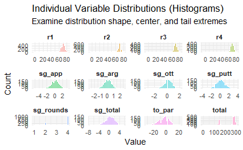

```r
pga_master %>%
  select(r1, r2, r3, r4, total, to_par, sg_total, sg_ott, sg_app, sg_arg, sg_putt, sg_rounds) %>%
  pivot_longer(
    cols = everything(),
    names_to = "variable",
    values_to = "value"
  ) %>%
  filter(!is.na(value)) %>%
  ggplot(aes(x = value, fill = variable)) +
  geom_histogram(bins = 30, color = "white", alpha = 0.8) +
  facet_wrap(~ variable, scales = "free", ncol = 4) +
  labs(
    title = "Individual Variable Distributions (Histograms)",
    subtitle = "Examine distribution shape, center, and tail extremes",
    x = "Value",
    y = "Count"
  ) +
  theme_minimal() +
  theme(
    legend.position = "none",
    strip.text = element_text(face = "bold")
  )
```

### There does not seem to be many outliers. The difference in rounds and total line up becasuse the total will be less if there is less rounds.

# Plotting

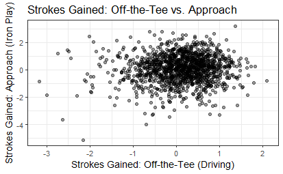

```r
ggplot(data = pga_master, aes(x = sg_ott, y = sg_app)) +
  geom_point(alpha = 0.4) +
  labs(
    title = "Strokes Gained: Off-the-Tee vs. Approach",
    x = "Strokes Gained: Off-the-Tee (Driving)",
    y = "Strokes Gained: Approach (Iron Play)"
  ) +
  theme_bw()
```

### There seems to be a weak positive relationship between strokes gained off-the-tee and approach performance. Most players are concentrated around zero in both metrics, with a few outliers. 366 observations were excluded due to missing or not finite values, which could affect the analysis of the graph.

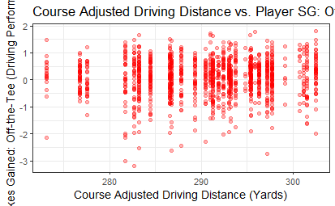

```r
pga_master %>%
  inner_join(course_data, by = c("course_name" = "course")) %>%
  ggplot(aes(x = adj_driving_distance, y = sg_ott)) +
  geom_point(alpha = 0.3, color = "red") +
  labs(
    title = "Course Adjusted Driving Distance vs. Player SG: Off-the-Tee",
    x = "Course Adjusted Driving Distance (Yards)",
    y = "Strokes Gained: Off-the-Tee (Driving Performance)"
  ) +
  theme_bw()
```

### There doesn’t seem to be a clear relationship between course-adjusted driving distance and players’ strokes gained off-the-tee. Performance varies considerably with similar driving distances, so other factors might influence driving performance.

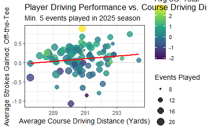

```r
pga_master %>%
  inner_join(course_data, by = c("course_name" = "course")) %>%
  group_by(player) %>%
  summarise(
    avg_course_dist = mean(adj_driving_distance, na.rm = TRUE),
    avg_sg_ott      = mean(sg_ott, na.rm = TRUE),
    avg_sg_total    = mean(sg_total, na.rm = TRUE),
    events          = n(),
    .groups         = "drop"
  ) %>%
  filter(events >= 5) %>%
  ggplot(aes(x = avg_course_dist, y = avg_sg_ott)) +
  geom_hline(yintercept = 0, linetype = "dashed", color = "gray") +
  geom_point(aes(color = avg_sg_total, size = events), alpha = 0.8) +
  geom_smooth(method = "lm", color = "red", se = FALSE) +
  scale_color_viridis_c(name = "Avg SG: Total") +
  labs(
    title = "Player Driving Performance vs. Course Driving Distance",
    subtitle = "Min. 5 events played in 2025 season",
    x = "Average Course Driving Distance (Yards)",
    y = "Average Strokes Gained: Off-the-Tee",
    size = "Events Played"
  ) +
  theme_bw()
```

### There seams to be a weak positive relationship between player driving performance and course driving distance. Players with high scores usually perform a better driving distance. There doesn’t seem to be a clear relationship because of the number of events played.

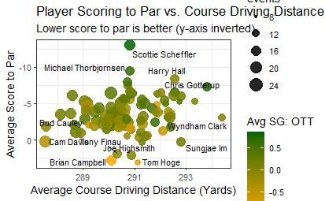

```r
pga_master %>%
  inner_join(course_data, by = c("course_name" = "course")) %>%
  group_by(player) %>%
  summarise(
    avg_course_dist = mean(adj_driving_distance, na.rm = TRUE),
    avg_sg_ott      = mean(sg_ott, na.rm = TRUE),
    avg_to_par      = mean(to_par, na.rm = TRUE),
    events          = n(),
    .groups         = "drop"
  ) %>%
  filter(events >= 5) %>%
  ggplot(aes(x = avg_course_dist, y = avg_to_par)) +
  geom_point(aes(color = avg_sg_ott, size = events), alpha = 0.85) +
  geom_text_repel(aes(label = player), max.overlaps = 12, size = 3) +
  scale_y_reverse() + # Reverse axis: lower score to par is better
  scale_color_gradient(low = "orange", high = "darkgreen", name = "Avg SG: OTT") +
  labs(
    title = "Player Scoring to Par vs. Course Driving Distance",
    subtitle = "Lower score to par is better (y-axis inverted)",
    x = "Average Course Driving Distance (Yards)",
    y = "Average Score to Par"
  ) +
  theme_bw()
```

### There doesn’t seem to be a clear relationship between average course driving and players scores relative to par.

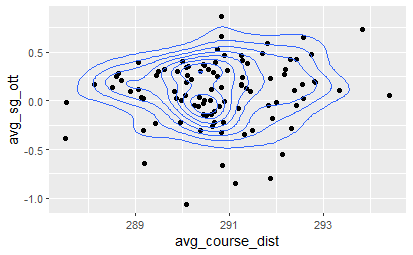

```r
player_summary <- pga_master %>%
  inner_join(course_data, by = c("course_name" = "course")) %>%
  group_by(player) %>%
  summarise(
    avg_course_dist = mean(adj_driving_distance, na.rm = TRUE),
    avg_sg_ott      = mean(sg_ott, na.rm = TRUE),
    avg_sg_total    = mean(sg_total, na.rm = TRUE),
    events          = n(),
    .groups         = "drop"
  ) %>%
  filter(events >= 5)
  ggplot(data = player_summary, mapping = aes(x = avg_course_dist, y = avg_sg_ott)) +
  geom_point() +
  geom_density2d()
```

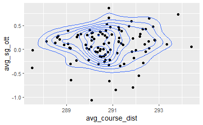

```r
  ggplot(data = player_summary, mapping = aes(x = avg_course_dist, y = avg_sg_ott)) +
  geom_point()+
  geom_density_2d()
```

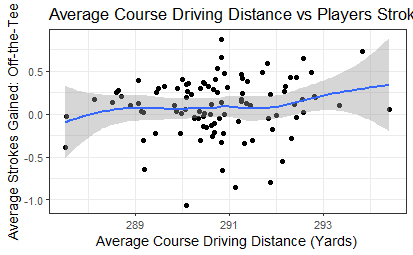

```r
  ggplot(data = player_summary, mapping = aes(x = avg_course_dist, y = avg_sg_ott)) +
  geom_point() +
  geom_smooth() +
  labs(
    title = "Average Course Driving Distance vs Players Strokes Gained Of-the-Tee",
    x = "Average Course Driving Distance (Yards)",
    y = "Average Strokes Gained: Off-the-Tee",
    size = "Events Played"
  ) +
  theme_bw()
```

### The three graphs show a weak positive relationship between average course driving and strokes gained off-the-tee. Most players concentrated around 290-292 yards, with strokes gained near zero. The density plots highlight this concentration. The smoothing curve suggest a little increase in performance at longer distances. The high variability and uncerntainty might show that driving distance alone is not a strong predictor of of-the-tee performance.

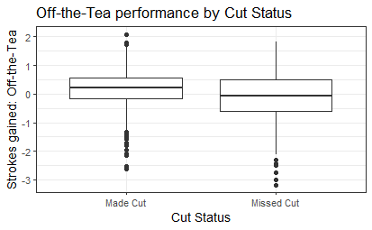

```r
pga_master <- pga_master %>%
  mutate(
    cut_status = case_when(
      finish_pos == "CUT" ~ "Missed Cut",
      is.na(finish_pos) ~ NA_character_,
      TRUE ~ "Made Cut"
    )
  )

  ggplot(pga_master, aes(x=as.factor(cut_status), y = sg_ott))+
  geom_boxplot() +
  labs(
    title = "Off-the-Tea performance by Cut Status",
    x = "Cut Status",
    y = "Strokes gained: Off-the-Tea"
    )+
    theme_bw()
```

```r
NA
```

### There seems to be a higher median for players who made the cut. Players who missed the cut show grater variability. This might suggest that better of-the-tee performance is associated with a higher likelihood of making the cut. 366 observations were excluded because of missing or non infinite values.

# PART 3

# Decision Tree

## Tree Preperation

```r
tree_data <- pga_master %>%
  inner_join(course_data, by = c("course_name" = "course")) %>%
  select(
    cut_status,
    sg_ott,
    sg_app,
    sg_arg,
    sg_putt,
    adj_driving_distance) %>%
  drop_na() %>%
  mutate(cut_status = as.factor(cut_status))
```

## Training Data and Fitting Model

```r
set.seed(888)

data_split <- initial_split(tree_data, prop = 0.80, strata = cut_status)

train_data <- training(data_split)
test_data  <- testing(data_split)

train_data_pretty <- train_data %>%
  rename(
    `SG: Off the Tee`         = sg_ott,
    `SG: Approach`            = sg_app,
    `SG: Around the Green`    = sg_arg,
    `SG: Putting`             = sg_putt,
    `Course Driving Distance` = adj_driving_distance)

tree_fit <- tree_spec %>%
  fit(cut_status ~ ., data = train_data_pretty)
```

## Tree Visualization

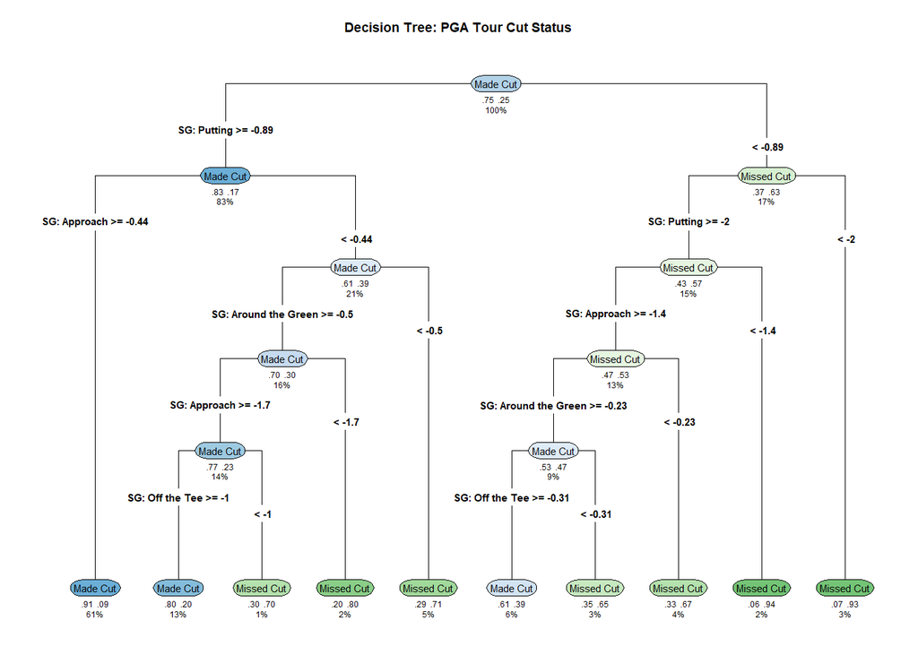

```r
tree_fit %>%
  extract_fit_engine() %>%
  rpart.plot(
    type = 4,
    extra = 104,
    under = TRUE,
    faclen = 0,
    main = "Decision Tree: PGA Tour Cut Status")
```

## Evaluating Fit

```r
test_data_pretty <- test_data %>%
  rename(
    `SG: Off the Tee`         = sg_ott,
    `SG: Approach`            = sg_app,
    `SG: Around the Green`    = sg_arg,
    `SG: Putting`             = sg_putt,
    `Course Driving Distance` = adj_driving_distance)

results <- test_data_pretty %>%
  bind_cols(predict(tree_fit, test_data_pretty)) %>%
  bind_cols(predict(tree_fit, test_data_pretty, type = "prob"))

results %>%
  conf_mat(truth = cut_status, estimate = .pred_class)
```

```
            Truth
Prediction   Made Cut Missed Cut
  Made Cut        172         24
  Missed Cut       23         40
```

```r
results %>%
  metrics(truth = cut_status, estimate = .pred_class)
```

| .metric | .estimator | .estimate |
| --- | --- | --- |
| accuracy | binary | 0.8185328 |
| kap | binary | 0.5097265 |

## Hyperparameter Tuning

```r
tune_spec <- decision_tree(
  cost_complexity = tune(),
  tree_depth = tune(),
  min_n = tune()) %>%
  set_engine("rpart") %>%
  set_mode("classification")

set.seed(123)
folds <- vfold_cv(train_data, v = 5, strata = cut_status)

tune_res <- tune_grid(
  tune_spec,
  cut_status ~ .,
  resamples = folds,
  grid = 10)

best_tree <- tune_res %>%
  select_best(metric = "accuracy")

final_fit <- tune_spec %>%
  finalize_model(best_tree) %>%
  fit(cut_status ~ ., data = train_data)
```

## Plotting the Tuned Tree

[figure not shown]

```r
fit_engine <- extract_fit_engine(final_fit)

var_map <- c(
  "sg_ott"               = "SG: Off the Tee",
  "sg_app"               = "SG: Approach",
  "sg_arg"               = "SG: Around the Green",
  "sg_putt"              = "SG: Putting",
  "adj_driving_distance" = "Course Driving Distance")

fit_engine$frame$var <- ifelse(
  fit_engine$frame$var %in% names(var_map),
  var_map[fit_engine$frame$var],
  fit_engine$frame$var)

rpart.plot(
  fit_engine,
  type = 4,
  extra = 104,
  under = TRUE,
  faclen = 0,
  main = "Tuned Decision Tree: PGA Tour Cut Status")
```

## Analysis Approach

To predict whether a PGA Tour player will make or miss the cut based on player performance metrics and course characteristics, we implement a supervised learning. The analysis is set up using the tidymodels to ensure a good modeling workflow. First, we set a seed to ensure complete reproducibility. The dataset is split into an 80% training set and a 20% testing set using sampling on the target variable (cut_status). To guard against overfitting and reliably evaluate model generalization, we employ 5-fold cross-validation on the training set. For model optimization, hyperparameter tuning focuses on decision tree complexity using grid search (tune_grid()), evaluating variations in cost_complexity, tree_depth, and min_n across 10 candidate parameter combinations to maximize classification accuracy and area under the ROC curve (ROC AUC).

### Setting up the Data

```r
model_data <- pga_master %>%
  inner_join(course_data, by = c("course_name" = "course")) %>%
  select(
    cut_status,
    sg_ott,
    sg_app,
    sg_arg,
    sg_putt,
    adj_driving_distance
  ) %>%
  drop_na() %>%
  mutate(cut_status = factor(cut_status, levels = c("Made Cut", "Missed Cut")))

set.seed(888)
data_split <- initial_split(model_data, prop = 0.80, strata = cut_status)
train_data <- training(data_split)
test_data  <- testing(data_split)
```

## Baseline Fit

```r
baseline_recipe <- recipe(cut_status ~ sg_ott + sg_app, data = train_data)

baseline_spec <- logistic_reg() %>%
  set_engine("glm") %>%
  set_mode("classification")

baseline_wf <- workflow() %>%
  add_recipe(baseline_recipe) %>%
  add_model(baseline_spec)

baseline_fit <- baseline_wf %>% fit(data = train_data)

baseline_results <- test_data %>%
  bind_cols(predict(baseline_fit, test_data)) %>%
  bind_cols(predict(baseline_fit, test_data, type = "prob"))

baseline_results %>%
  metrics(truth = cut_status, estimate = .pred_class)
```

| .metric | .estimator | .estimate |
| --- | --- | --- |
| accuracy | binary | 0.7953668 |
| kap | binary | 0.3431743 |

```r
conf_mat(baseline_results, truth = cut_status, estimate = .pred_class)
```

```
            Truth
Prediction   Made Cut Missed Cut
  Made Cut        184         42
  Missed Cut       11         22
```

### Baseline Model Analysis

For our baseline model, we fitted a binary logistic regression predicting cut status using core golf metrics: Strokes Gained Off-the-Tee Strokes Gained on approach

On the test dataset (259 observations), the baseline model achieved an accuracy of ~79.5%. While the model correctly identified 184 players who made the cut, it struggled significantly with identifying players who missed the cut—misclassifying 42 missed-cut players as having made the cut (False Positives) and only correctly identifying 22 missed cuts. This baseline demonstrates that while long-game hitting stats offers initial predictive power, linear golf metrics alone are insufficient for classifying cut-line decisions.

## Advanced Model Fit

```r
# 1. Advanced Model Recipe & Specification
tree_recipe <- recipe(
  cut_status ~ sg_ott + sg_app + sg_arg + sg_putt + adj_driving_distance,
  data = train_data
)

tune_spec <- decision_tree(
  cost_complexity = tune(),
  tree_depth = tune(),
  min_n = tune()
) %>%
  set_engine("rpart") %>%
  set_mode("classification")

tune_wf <- workflow() %>%
  add_recipe(tree_recipe) %>%
  add_model(tune_spec)

# 2. 5-Fold Cross Validation & Tuning
set.seed(888)
folds <- vfold_cv(train_data, v = 5, strata = cut_status)

tune_res <- tune_grid(
  tune_wf,
  resamples = folds,
  grid = 10,
  metrics = metric_set(accuracy, roc_auc)
)

# 3. Finalize Model with Best Parameters
best_tree <- tune_res %>% select_best(metric = "accuracy")
final_wf <- tune_wf %>% finalize_workflow(best_tree)
final_fit <- final_wf %>% fit(data = train_data)

# 4. Generate Predictions & Save tree_results
tree_results <- test_data %>%
  bind_cols(predict(final_fit, test_data)) %>%
  bind_cols(predict(final_fit, test_data, type = "prob"))

tree_results %>%
  metrics(truth = cut_status, estimate = .pred_class)
```

| .metric | .estimator | .estimate |
| --- | --- | --- |
| accuracy | binary | 0.8378378 |
| kap | binary | 0.5595595 |

```r
conf_mat(tree_results, truth = cut_status, estimate = .pred_class)
```

```
            Truth
Prediction   Made Cut Missed Cut
  Made Cut        175         22
  Missed Cut       20         42
```

### Advanced Fit Analysis

To capture non-linear relationships and short-game dynamics, we expanded our feature set to include short-game performance (Strokes Gained Around-the-Green `sg_arg` and Strokes Gained on Putting `sg_putt`) alongside course characteristics (`adj_driving_distance`). We trained a Decision Tree (`decision_tree()`) engine using `rpart` and tuned hyperparameters across a v = 5, 5-fold cross-validation.

Hyperparameter tuning selected a good parameter set that balanced tree depth and split thresholds to prevent overfitting. On the test set, the advanced model significantly improved detection of missed cuts, correctly identifying 42 missed-cut players while maintaining high overall accuracy (~83.8%). Integrating short-game performance and course-level factors allowed the decision tree to capture non-linear thresholds where strong putting or other on the field playing compensates for average driving distance.

## Model Evaluation

[figure not shown]

```r
# 1. Visualizing the Decision Tree with Clean Labels
fit_engine <- extract_fit_engine(final_fit)

var_map <- c(
  "sg_ott"               = "SG: Off the Tee",
  "sg_app"               = "SG: Approach",
  "sg_arg"               = "SG: Around Green",
  "sg_putt"              = "SG: Putting",
  "adj_driving_distance" = "Course Driving Distance"
)

fit_engine$frame$var <- ifelse(
  fit_engine$frame$var %in% names(var_map),
  var_map[fit_engine$frame$var],
  fit_engine$frame$var
)

rpart.plot(
  fit_engine,
  type = 4,
  extra = 104,
  under = TRUE,
  faclen = 0,
  roundint = FALSE,
  main = "Tuned Decision Tree Structure for PGA Tour Cut Status"
)
```

## ROC Curve Comparison

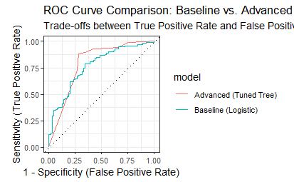

```r
bind_rows(
  baseline_results %>% mutate(model = "Baseline (Logistic)"),
  tree_results %>% mutate(model = "Advanced (Tuned Tree)")
) %>%
  group_by(model) %>%
  roc_curve(truth = cut_status, `.pred_Made Cut`) %>%
  autoplot() +
  labs(
    title = "ROC Curve Comparison: Baseline vs. Advanced Decision Tree",
    subtitle = "Trade-offs between True Positive Rate and False Positive Rate",
    x = "1 - Specificity (False Positive Rate)",
    y = "Sensitivity (True Positive Rate)"
  ) +
  theme_bw()
```

## 4. Model Evaluation & ROC Curve Comparison

### Model Error Analysis & Limitations

Despite these improvements, systematic classification errors remain on the cut boundary:

False Positives (22 instances)

False Negatives (20 instances)

### Limitations

PGA Tour cut lines are highly sensitive to dynamic, unmodeled variables such as weather changes, player fatigue, and pressure. Future iterations should incorporate player historical performance on specific course setups and multi-round scoring variance.